# Online Retail Sales Analysis

## Project Overview

**Dataset:** UCI Online Retail Dataset (2009-2011)  
**Goal:** Practice end-to-end data analysis using Python to identify sales patterns and business insights

This analysis answers **4 key business questions** to practice data analysis skills:

1. Which products generate the most revenue?
2. Who are our most valuable customers?
3. What are our sales trends over time?
4. What's our average order value?

## Business Context

This dataset contains transactions from a UK-based online retailer selling unique gift items. The company serves both individual customers and wholesalers across multiple countries.

**Key Metrics to Analyze:**

- Revenue drivers (products and customers)
- Seasonal patterns and trends
- Purchase behavior and order values

**Tools Used:** Python, pandas, matplotlib, Jupyter Notebook

```python
import pandas as pd
import numpy as np
import matplotlib.pyplot as plt

print("Libraries loaded successfully!")
```

```
Libraries loaded successfully!
```

```python
df = pd.read_csv("online_retail_II.csv", encoding='latin-1')
print(f"Dataset shape: {df.shape[0]:,} rows × {df.shape[1]} columns")
print(f"\nColumn names: {list(df.columns)}")

df.head()
```

```
Dataset shape: 1,048,575 rows × 8 columns

Column names: ['Invoice', 'StockCode', 'Description', 'Quantity', 'InvoiceDate', 'Price', 'Customer ID', 'Country']
```

|  | Invoice | StockCode | Description | Quantity | InvoiceDate | Price | Customer ID | Country |
| --- | --- | --- | --- | --- | --- | --- | --- | --- |
| 0 | 489434 | 85048 | 15CM CHRISTMAS GLASS BALL 20 LIGHTS | 12 | 12-01-2009 07:45 | 6.95 | 13085.0 | United Kingdom |
| 1 | 489434 | 79323P | PINK CHERRY LIGHTS | 12 | 12-01-2009 07:45 | 6.75 | 13085.0 | United Kingdom |
| 2 | 489434 | 79323W | WHITE CHERRY LIGHTS | 12 | 12-01-2009 07:45 | 6.75 | 13085.0 | United Kingdom |
| 3 | 489434 | 22041 | RECORD FRAME 7" SINGLE SIZE | 48 | 12-01-2009 07:45 | 2.1 | 13085.0 | United Kingdom |
| 4 | 489434 | 21232 | STRAWBERRY CERAMIC TRINKET BOX | 24 | 12-01-2009 07:45 | 1.25 | 13085.0 | United Kingdom |

```python
print("="*60)
print("DATA QUALITY CHECK")
print("="*60)

print("\n1. Data types and non-null counts:")
df.info()

print("\n" + "="*60)
print("2. Missing values per column:")
print(df.isnull().sum())

print("\n" + "="*60)
print("3. Basic statistics for numeric columns:")
df.describe()
```

```
============================================================
DATA QUALITY CHECK
============================================================

1. Data types and non-null counts:
<class 'pandas.core.frame.DataFrame'>
RangeIndex: 1048575 entries, 0 to 1048574
Data columns (total 8 columns):
 #   Column       Non-Null Count    Dtype
---  ------       --------------    -----
 0   Invoice      1048575 non-null  object
 1   StockCode    1048575 non-null  object
 2   Description  1044203 non-null  object
 3   Quantity     1048575 non-null  object
 4   InvoiceDate  1048575 non-null  object
 5   Price        1048575 non-null  object
 6   Customer ID  811893 non-null   object
 7   Country      1048575 non-null  object
dtypes: object(8)
memory usage: 64.0+ MB

============================================================
2. Missing values per column:
Invoice             0
StockCode           0
Description      4372
Quantity            0
InvoiceDate         0
Price               0
Customer ID    236682
Country             0
dtype: int64

============================================================
3. Basic statistics for numeric columns:
```

|  | Invoice | StockCode | Description | Quantity | InvoiceDate | Price | Customer ID | Country |
| --- | --- | --- | --- | --- | --- | --- | --- | --- |
| count | 1048575 | 1048575 | 1044203 | 1048575 | 1048575 | 1048575.00 | 811893.0 | 1048575 |
| unique | 52962 | 5305 | 5693 | 1281 | 47047 | 3119.00 | 7085.0 | 44 |
| top | 537434 | 85123A | WHITE HANGING HEART T-LIGHT HOLDER | 1 | 12-06-2010 16:57 | 1.25 | 17841.0 | United Kingdom |
| freq | 1350 | 5781 | 5875 | 266749 | 1350 | 97423.00 | 12255.0 | 963818 |

```python
df_clean = df.copy()

print("CLEANING DATA...")
print(f"Starting rows: {df_clean.shape[0]:,}")

print(f"After removing missing Customer ID: {df_clean.shape[0]:,}")

df_clean['Quantity'] = pd.to_numeric(df_clean['Quantity'], errors='coerce')
df_clean = df_clean[df_clean['Quantity'] > 0]
print(f"After removing returns: {df_clean.shape[0]:,}")

df_clean['Price'] = pd.to_numeric(df_clean['Price'], errors='coerce')
df_clean = df_clean[df_clean['Price'] > 0]
print(f"After removing invalid prices: {df_clean.shape[0]:,}")

df_clean['TotalRevenue'] = df_clean['Quantity'] * df_clean['Price']

df_clean['InvoiceDate'] = pd.to_datetime(df_clean['InvoiceDate'], format='mixed', dayfirst=True, errors='coerce')

df_clean['Year'] = df_clean['InvoiceDate'].dt.year
df_clean['Month'] = df_clean['InvoiceDate'].dt.month
df_clean['MonthName'] = df_clean['InvoiceDate'].dt.month_name()

print("\n" + "="*60)
print(f"✅ CLEANING COMPLETE!")
print(f"Final dataset: {df_clean.shape[0]:,} rows × {df_clean.shape[1]} columns")
print(f"Removed: {df.shape[0] - df_clean.shape[0]:,} invalid rows")
print("="*60)

df_clean.head()
```

```
CLEANING DATA...
Starting rows: 1,048,575
After removing missing Customer ID: 1,048,575
After removing returns: 1,025,877
After removing invalid prices: 1,023,143

============================================================
✅ CLEANING COMPLETE!
Final dataset: 1,023,143 rows × 12 columns
Removed: 25,432 invalid rows
============================================================
```

|  | Invoice | StockCode | Description | Quantity | InvoiceDate | Price | Customer ID | Country | TotalRevenue | Year | Month | MonthName |
| --- | --- | --- | --- | --- | --- | --- | --- | --- | --- | --- | --- | --- |
| 0 | 489434 | 85048 | 15CM CHRISTMAS GLASS BALL 20 LIGHTS | 12.0 | 2009-01-12 07:45:00 | 6.95 | 13085.0 | United Kingdom | 83.4 | 2009 | 1 | January |
| 1 | 489434 | 79323P | PINK CHERRY LIGHTS | 12.0 | 2009-01-12 07:45:00 | 6.75 | 13085.0 | United Kingdom | 81.0 | 2009 | 1 | January |
| 2 | 489434 | 79323W | WHITE CHERRY LIGHTS | 12.0 | 2009-01-12 07:45:00 | 6.75 | 13085.0 | United Kingdom | 81.0 | 2009 | 1 | January |
| 3 | 489434 | 22041 | RECORD FRAME 7" SINGLE SIZE | 48.0 | 2009-01-12 07:45:00 | 2.10 | 13085.0 | United Kingdom | 100.8 | 2009 | 1 | January |
| 4 | 489434 | 21232 | STRAWBERRY CERAMIC TRINKET BOX | 24.0 | 2009-01-12 07:45:00 | 1.25 | 13085.0 | United Kingdom | 30.0 | 2009 | 1 | January |

# Business Analysis & Insights

Now we'll answer key business questions using the clean data.

## Question 1: Which Products Generate the Most Revenue?

```
============================================================
TOP 15 PRODUCTS BY REVENUE
============================================================
 1. Manual                                   $  340,677.44
 2. REGENCY CAKESTAND 3 TIER                 $  339,301.55
 3. DOTCOM POSTAGE                           $  304,989.94
 4. WHITE HANGING HEART T-LIGHT HOLDER       $  265,164.66
 5. JUMBO BAG RED RETROSPOT                  $  149,909.27
 6. PARTY BUNTING                            $  148,600.11
 7. ASSORTED COLOUR BIRD ORNAMENT            $  131,016.46
 8. POSTAGE                                  $  125,471.13
 9. PAPER CHAIN KIT 50'S CHRISTMAS           $  117,918.75
10. CHILLI LIGHTS                            $   83,775.65
11. MEDIUM CERAMIC TOP STORAGE JAR           $   81,492.97
12. ROTATING SILVER ANGELS T-LIGHT HLDR      $   72,487.68
13. JUMBO BAG STRAWBERRY                     $   69,474.46
14. BLACK RECORD COVER FRAME                 $   63,992.18
15. JUMBO STORAGE BAG SUKI                   $   61,794.91
```

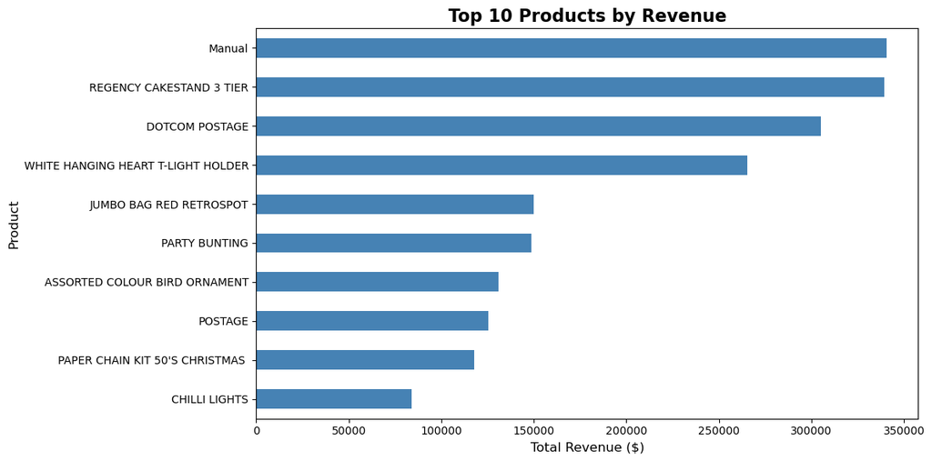

```
💡 Insight: Top 10 products account for 9.8% of total revenue
```

```python
product_revenue = df_clean.groupby('Description')['TotalRevenue'].sum().sort_values(ascending=False).head(15)

print("="*60)
print("TOP 15 PRODUCTS BY REVENUE")
print("="*60)
for i, (product, revenue) in enumerate(product_revenue.items(), 1):
    print(f"{i:2}. {product[:40]:40} ${revenue:>12,.2f}")

plt.figure(figsize=(12, 6))
product_revenue.head(10).plot(kind='barh', color='steelblue')
plt.title('Top 10 Products by Revenue', fontsize=16, fontweight='bold')
plt.xlabel('Total Revenue ($)', fontsize=12)
plt.ylabel('Product', fontsize=12)
plt.gca().invert_yaxis()
plt.tight_layout()
plt.show()

total_revenue = df_clean['TotalRevenue'].sum()
top10_revenue = product_revenue.head(10).sum()
top10_pct = (top10_revenue / total_revenue) * 100

print(f"\n💡 Insight: Top 10 products account for {top10_pct:.1f}% of total revenue")
```

## Question 2: Who Are Our Top Customers?

Understanding customer value helps prioritize retention efforts.

```
============================================================
TOP 10 CUSTOMERS BY TOTAL SPENDING
============================================================
 1. Customer # 18102    $  569,501.50
 2. Customer # 14646    $  490,171.52
 3. Customer # 14156    $  296,849.45
 4. Customer # 14911    $  281,209.14
 5. Customer # 17450    $  226,324.05
 6. Customer # 13694    $  187,843.73
 7. Customer # 17511    $  157,651.01
 8. Customer # 16684    $  138,627.39
 9. Customer # 12415    $  137,365.39
10. Customer # 17949    $  114,938.08

📊 Customer Statistics:
   Total unique customers: 6,953
   Average spending per customer: $2,491.72
   Median spending: $720.90
   Top 10% threshold: $4,655.74
```

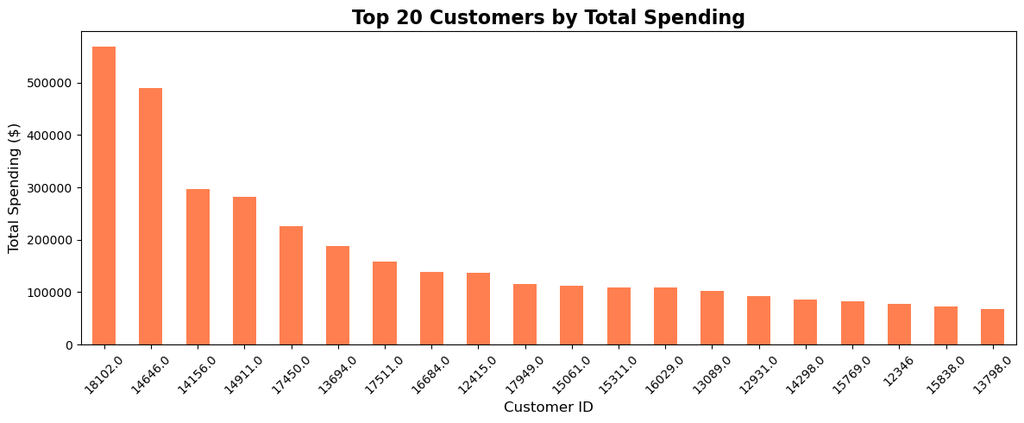

```
💡 Insight: Top 20% of customers (1,390 customers) generate 77.3% of revenue
   → Classic Pareto principle in action!
```

```python
customer_spending = df_clean.groupby('Customer ID')['TotalRevenue'].sum().sort_values(ascending=False)

print("="*60)
print("TOP 10 CUSTOMERS BY TOTAL SPENDING")
print("="*60)
for i, (customer_id, spending) in enumerate(customer_spending.head(10).items(), 1):
    print(f"{i:2}. Customer #{int(customer_id):>6}    ${spending:>12,.2f}")

print(f"\n📊 Customer Statistics:")
print(f"   Total unique customers: {df_clean['Customer ID'].nunique():,}")
print(f"   Average spending per customer: ${customer_spending.mean():,.2f}")
print(f"   Median spending: ${customer_spending.median():,.2f}")
print(f"   Top 10% threshold: ${customer_spending.quantile(0.90):,.2f}")

plt.figure(figsize=(12, 5))
customer_spending.head(20).plot(kind='bar', color='coral')
plt.title('Top 20 Customers by Total Spending', fontsize=16, fontweight='bold')
plt.xlabel('Customer ID', fontsize=12)
plt.ylabel('Total Spending ($)', fontsize=12)
plt.xticks(rotation=45)
plt.tight_layout()
plt.show()

top20pct_customers = int(len(customer_spending) * 0.2)
top20pct_revenue = customer_spending.head(top20pct_customers).sum()
total_revenue = customer_spending.sum()
pct_contribution = (top20pct_revenue / total_revenue) * 100

print(f"\n💡 Insight: Top 20% of customers ({top20pct_customers:,} customers) generate {pct_contribution:.1f}% of revenue")
print(f"   → Classic Pareto principle in action!")
```

## Question 3: What Are Our Sales Trends Over Time?

Understanding seasonality helps with inventory planning and forecasting.

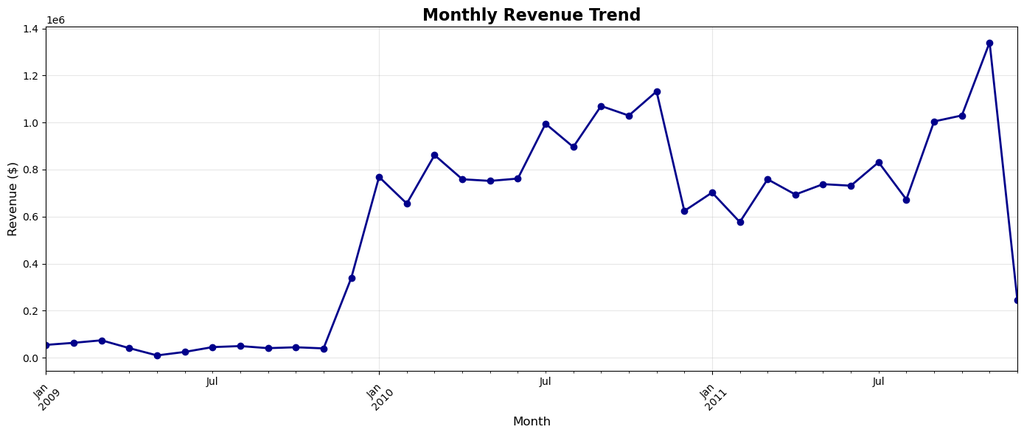

```
============================================================
SEASONAL INSIGHTS
============================================================
📈 Peak sales month: November ($2,512,277.82 total)
📉 Lowest sales month: December ($1,208,327.95 total)

💡 Insight: Clear seasonality detected!
   → Plan inventory and staffing for November
   → Run promotions during December to boost sales
```

```python
df_clean['YearMonth'] = df_clean['InvoiceDate'].dt.to_period('M')
monthly_revenue = df_clean.groupby('YearMonth')['TotalRevenue'].sum()

plt.figure(figsize=(14, 6))
monthly_revenue.plot(kind='line', marker='o', linewidth=2, color='darkblue')
plt.title('Monthly Revenue Trend', fontsize=16, fontweight='bold')
plt.xlabel('Month', fontsize=12)
plt.ylabel('Revenue ($)', fontsize=12)
plt.grid(True, alpha=0.3)
plt.xticks(rotation=45)
plt.tight_layout()
plt.show()

monthly_totals = df_clean.groupby('Month')['TotalRevenue'].sum().sort_values(ascending=False)
peak_month = monthly_totals.index[0]
low_month = monthly_totals.index[-1]

month_names = {1:'January', 2:'February', 3:'March', 4:'April', 5:'May', 6:'June',
               7:'July', 8:'August', 9:'September', 10:'October', 11:'November', 12:'December'}

print("="*60)
print("SEASONAL INSIGHTS")
print("="*60)
print(f"📈 Peak sales month: {month_names[peak_month]} (${monthly_totals.iloc[0]:,.2f} total)")
print(f"📉 Lowest sales month: {month_names[low_month]} (${monthly_totals.iloc[-1]:,.2f} total)")
print(f"\n💡 Insight: Clear seasonality detected!")
print(f"   → Plan inventory and staffing for {month_names[peak_month]}")
print(f"   → Run promotions during {month_names[low_month]} to boost sales")
```